# Krishnakant A - Time Series Analysis

## Introduction

### Resources

- Time series analysis by James D Hamilton - its considered to be the bible on time series analysis, pretty much covers all the theory , it doesnt have any code or pseudocode
- Introduction to Time Series with R by Metcalfe & Coweperwait
- Analysis of Financial Time Series by Tsay

### Aim and Motivation

- Would be exploring time series analysis in the context of finance
- Implementing code from the book by Tsay , would be using the book by Hamilton and Metcalfe as reference
- Aim to understand different time series models in R.
- (Will keep on expanding this section on the go)

## Financial Time Series and Linear Time series

### Asset Returns

**Definition 1 (Simple gross return)**  
Arithmetic Returns

$$P_t = P_{t-1}(1+R_t) \implies R_t = \frac{P_t - P_{t-1}}{P_t}$$
where $P_t$ and $R_t$ are the price and return at time $t$ respectively
Continuously compounded return or log return

$$r_t = \ln(1+R_t)$$
Dividend Payment

$$r_t = \ln(P_t + D_t) -\ln(P_{t-1})$$
Where $D_t$ is dividend payment between time t-1 and time t .

**Definition 2 (Multiperiod gross return)**
Similiary we can define multiperiod simple return by
$$R_t[k] = exp{[\frac{1}{k}\sum_{j=0}^{k-1}(1+R_{t-j})]} -1$$
where exp is the exponentential function and k is total number periods the asset was held for.

Log return would be
$$r_t[k] = r_t +r_{t-1}+.....+r_{t-k+1}$$

**Definition 3 (Portfolio Return)**
$$R_{p,t}= \sum_{i=1}^{N}w_i R_{it}$$

Where $p$ is the portfolio , $i$ the ith asset and $w_i$ the weight of the $i^{th}$ asset in the portfolio

* Load data and header =T give the 1st row of the data file , that is the names of the cloumns of the data set

```r
# da contains the return for 5 five stocks and indexes namely IBM ,value-weighted , equal-weighted and S&P composite index from 1970 to 2008
library(fBasics)
da = read.table("TST/d-ibm3dx7008.txt",header = T)
dim(da) # dimensions for the data
```

```
[1] 9845    5
```

```r
da[1:5,]# first five rows
```

|  | Date | rtn | vwretd | ewretd | sprtrn |
| --- | --- | --- | --- | --- | --- |
| 1 | 19700102 | 0.000686 | 0.012137 | 0.033450 | 0.010211 |
| 2 | 19700105 | 0.009596 | 0.006375 | 0.018947 | 0.004946 |
| 3 | 19700106 | 0.000679 | -0.007233 | -0.005776 | -0.006848 |
| 4 | 19700107 | 0.000678 | -0.001272 | 0.003559 | -0.002047 |
| 5 | 19700108 | 0.002034 | 0.000564 | 0.002890 | 0.000540 |

```r
tail(da)#Last 5 rows
```

|  | Date | rtn | vwretd | ewretd | sprtrn |
| --- | --- | --- | --- | --- | --- |
| 9840 | 20081223 | -0.016953 | -0.007618 | -0.008332 | -0.009717 |
| 9841 | 20081224 | -0.000993 | 0.004463 | 0.005254 | 0.005781 |
| 9842 | 20081226 | 0.010060 | 0.007170 | 0.011629 | 0.005356 |
| 9843 | 20081229 | -0.000984 | -0.004481 | -0.016514 | -0.003873 |
| 9844 | 20081230 | 0.028308 | 0.024951 | 0.021692 | 0.024407 |
| 9845 | 20081231 | 0.007301 | 0.017513 | 0.036731 | 0.014158 |

```r
ibm = da[,2] # IBM simple returns

sibm = ibm*100 #Percentage simple returns

b = basicStats(sibm)

s1 = skewness(sibm)
t = s1/sqrt(6/9845) #definition for test statistic here 9845 is N
pv  = 2*(1-pnorm(t)) # Calculate p-value

cat("skewness =", s1,"\nTest Satistic = ",t,"\np-value = ", pv)
```

```
skewness = 0.06139878
Test Satistic =  2.487093
p-value =  0.01287919
```

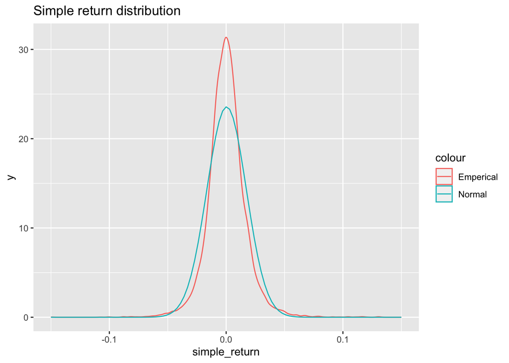

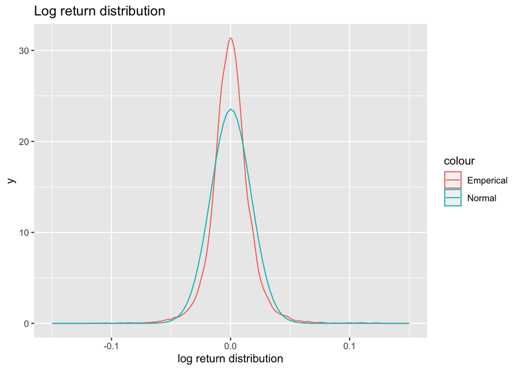

```r
library(ggplot2)
ibm = as.data.frame(da[,1:2])

ibm["log_return"] = log(1+ibm["rtn"])
colnames(ibm)[2] <- "simple_return"

ggplot(ibm,aes(x = simple_return,colour="Emperical"))+
      ggtitle("Simple return distribution") +
      xlim (-0.15,0.15)+
      geom_density()+
      stat_function(mapping = aes(colour ="Normal"),
                   fun = dnorm,args = with(ibm,c(mean =mean(simple_return),
                   sd = sd(simple_return))))
ggplot(ibm,aes(x = log_return,colour = "Emperical"))+
      ggtitle("Log return distribution")+
      xlim (-0.15,0.15)+geom_density()+
      stat_function(mapping = aes(colour = "Normal"),
             fun = dnorm,args = with(ibm,c(mean = mean(log_return),
             sd = sd(log_return))))+
scale_x_continuous("log return distribution",limits = c(-0.15,0.15))
```

```r
#IBM = ibm[, 2] # IBM simple return values
#IBM = ts(IBM,frequency = 250 ,start = c(1970,1))

#plot.ts(IBM)


#acf(IBM,lag=250,ylim= c(-0.05,0.05))#ACF is covered in detail down below , the x axis label is fraction of unit time

#libm = ibm[,2]*100
#length(libm)
#mean(libm)
#t.test(libm)
#k1 = kurtosis(libm)
#s1 =skewness(libm)
#t3  = (s1^2)/(6/9845)
#t2 = ((k1)^2)/(24/9845)
#3t2
#a = t2+t3
#a
#normalTest(libm,method = 'jb')
```

### Linear Time Series

Stationarity

Foundation of time series analysis is Stationarity. A time series $\{r_t\}$ is said to be strictly stationary if the joint distribution of $(r_{t_{1}},r_{t_{2}},r_{t_{3}},....,r_{t_{k}})$ is identical to that of $(r_{t_{1+t}},r_{t_{2+t}},r_{t_{3+t}},....,r_{t_{k+t}})$ for all $t$ , where $k$ is an arbitrary positive integer and $(t_1,t_2,t_3,....,t_k)$ is collection of $k$ positive integers. Strict stationarity is very hard to verify emperically  
A time series is said to be weakly stationary if the mean of $r_t$ and the covariance between $r_t$ and $r_{t-l}$ are time invariant where $l$ is an arbitrary integer. Weak stationarity enables us to make inference concerning future observations

- $\mathbb{E}(t_t) = \mu$
- $Cov(r_t,r_{t-l}) = \gamma_l$

Weak stationarity is commonly studied and more practical.

The covariance $\gamma_l = Cov(r_t,r_{t-l})$ is called the lag-$l$ autocovariance of $r_t$. From the above defintion it follows that

- $\gamma_0=Var(r_t)$
- $\gamma_{-l} = \gamma_l$

Autocorrelation Function

Consider a weakly stationary return series $r_t$. When the linear dependence between $r_t$ and its past values $r_{t-l}$ is of interest , the concept of correlation is generalised to autocorrelation. The correlation coefficient between $r_t$ and $r_{t-l}$ is called the lag-l autocorrelation of $r_t$ and is commonly denoted by $\rho_l$ , which under the weak stationarity assumption is a function of l only. Its defined by
$$\rho_l = \frac{Cov(r_t,r_{t-l})}{\sqrt{Var(r_t)Var(r_{t-l})}} = \frac{Cov(r_t,r_{t-l})}{Var(r_t)} = \frac{\gamma_l}{\gamma_0}$$

Its easy to see that

- $\rho_0 = 1$
- $\rho_l = \rho_{-l}$
- $-1\leq \rho_l \leq 1$

For a given sample of returns $\{r_t\}_{t=1}^T$ , let $\bar r$ be the sample mean. Then the lag-1 autocorrelation of $r_t$ is
$$\hat\rho_1 = \frac{\sum_{t=2}^T(r_t - \bar r)(r_{t-1} - \bar r)}{\sum_{t=2}^T(r_t - \bar r )^2}$$

The conditions under which $\hat\rho$ is a consistent estimator of $\rho_1$ are as follows :

- The returns $\{r_t\}$ is an independent and identically distributed sequence
- $\mathbb{E}(r_t^2) < \infty$

Then $\hat\rho_1$ is asymptotically normal with mean zero and variance 1/T

Testing

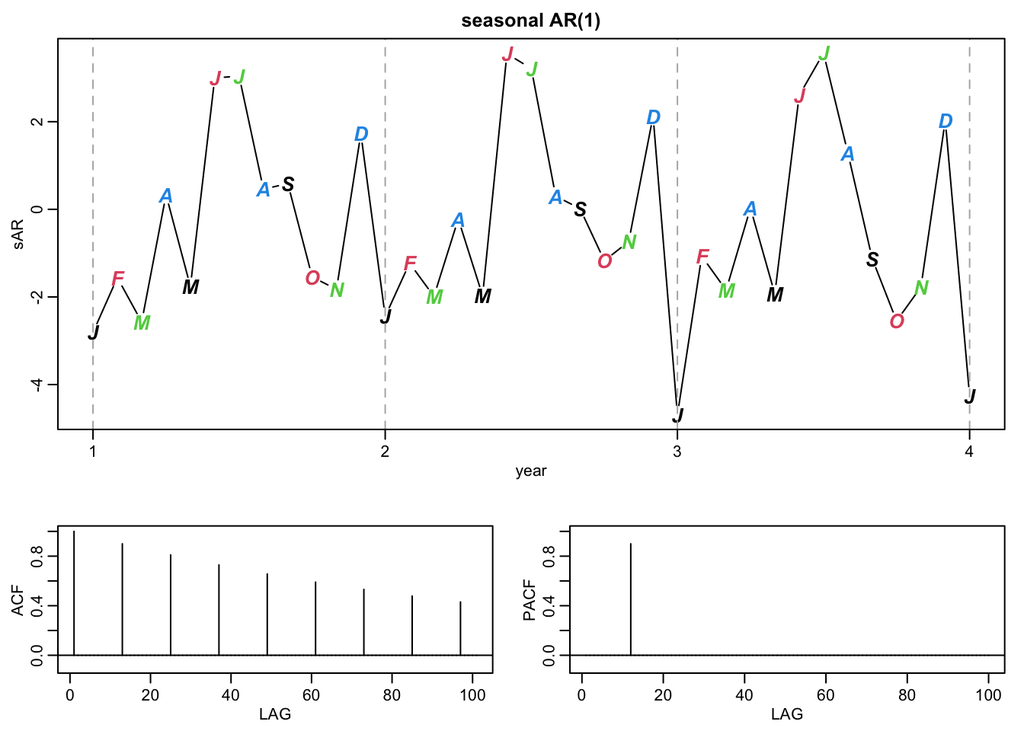

```r
set.seed(666)
phi = c(rep(0,11),.9)
sAR = arima.sim(list(order=c(12,0,0), ar=phi), n=37)
sAR = ts(sAR, freq=12)
layout(matrix(c(1,1,2, 1,1,3), nc=2))
par(mar=c(3,3,2,1), mgp=c(1.6,.6,0))
plot(sAR, axes=FALSE, main='seasonal AR(1)', xlab="year", type='c')
Months = c("J","F","M","A","M","J","J","A","S","O","N","D")
points(sAR, pch=Months, cex=1.25, font=4, col=1:4)
axis(1, 1:4); abline(v=1:4, lty=2, col=gray(.7))
axis(2); box()
ACF = ARMAacf(ar=phi, ma=0, 100)
PACF = ARMAacf(ar=phi, ma=0, 100, pacf=TRUE)
plot(ACF,type="h", xlab="LAG", ylim=c(-.1,1)); abline(h=0)
plot(PACF, type="h", xlab="LAG", ylim=c(-.1,1)); abline(h=0)
```